BLOQUE 5 DE 6

Decisiones prácticas y alcance

Estandarizar, métodos no lineales y casos aplicados.

# ¿Qué pasa si no estandarizamos?

Antes de mirar el resultado

Vamos a correr PCA sobre las ocho variables **sin estandarizar**. ¿Qué variable creen que va a dominar la primera componente, y por qué?

- La **nota de admisión** va de 0 a 200; las materias aprobadas, de 0 a 10.
- Sus varianzas: **210** frente a **9,6**.
- Como PCA busca máxima varianza, sin estandarizar la escala de medición decide el resultado.

# Sin escalar, una variable secuestra PC1

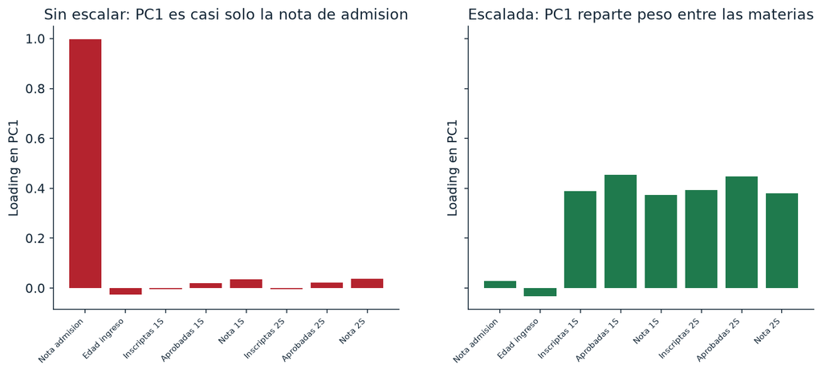

Pesos de PC1 sin escalar (izquierda) y escalando (derecha). Sin estandarizar, PC1 es **casi solo la nota de admisión**; estandarizando, reparte peso entre las materias y se vuelve interpretable. Salvo unidad común, se estandariza siempre.

# Más allá de PCA: t-SNE y UMAP

# Lo que t-SNE y UMAP no garantizan

Tres cuidados

- **No preservan distancias globales**: la separación entre dos grupos lejanos en el dibujo no es interpretable.
- **Dependen de hiperparámetros**: cambiar la *perplexity* o el número de vecinos cambia el gráfico.
- **Sus ejes no significan nada**: no hay loadings que interpretar.
- No están en el capítulo 12 del libro: son un complemento moderno.
- Regla: usalos para descubrir grupos, nunca para medir distancias.

# PC1 como índice: el Nivel Socioeconómico

Filmer y Pritchett (2001), *Demography*

Para estimar la riqueza del hogar sin datos de gasto, construyeron un **índice** a partir de indicadores de **posesión de bienes** del hogar, usando PCA para derivar los ponderadores.

- Los hogares se ordenan por su valor en **PC1** y se agrupan en **quintiles**, de más pobre a más rico.
- Vyas y Kumaranayake (2006) es la guía metodológica de referencia sobre cómo construirlo e interpretarlo.
- **Punto de discusión:** casi todos estos trabajos usan *solo* PC1. Hay literatura que propone combinar varias componentes, porque PC1 suele explicar una parte modesta de la varianza.

# 32 medidas de comportamiento, seis dimensiones

Arguello y Crescenzi (2019)

Analizaron con PCA hasta **32 medidas de comportamiento** por sesión (cantidad de búsquedas, clics, tiempos de permanencia, scrolls, movimientos del mouse) en estudios de búsqueda de información.

- Objetivo: entender qué **fenómenos latentes** capturan esas medidas, y cómo influyen en las percepciones posteriores (carga de trabajo, dificultad, *engagement*).
- Usaron la matriz de **correlación** y no la de covarianza, porque las medidas están en escalas muy distintas: es el mismo argumento del escalado que vimos recién.
- Para elegir cuántas componentes: autovalor **mayor a 1**, y que cada componente tenga al menos **dos variables** con pesos altos.

# Del componente al modelo

- Aplicaron una **rotación varimax**: redistribuye los pesos para que cada variable cargue fuerte en una sola componente. Facilita nombrarlas, y es práctica estándar aplicada aunque el libro no la desarrolle.
- Así nombraron cada dimensión según qué medidas pesaban en ella, por ejemplo *abandono de búsquedas* o *ritmo de interacción*.
- Después usaron los **scores** de las componentes, en lugar de las 32 medidas originales, como predictores de un modelo de regresión.

El resultado

Seis componentes explicaron el **76%** de la varianza de las medidas de comportamiento. El circuito completo: comportamiento crudo → dimensiones interpretables → efectos sobre lo que la gente percibe.